# stats20 final report

Lucy Shao

March 22, 2017

# Load the data.

### Load/Read the data files directly into R as received. Do not use other software to change the file formats.

### What are the dimensions of the original data?

```
## [1] 2445924      24
```

```
## [1] 288 111
```

```
## [1] 9248   22
```

### What are the observations of each dataset?

1.The Edmunds data passses dealerships the information about leads that are submitted from Edmunds.com. The lead information, the Visitors submit leads, and dealerships have a unique ids.The data provides information about the cars the visitors submitted on Edmunds.com, including the unique ids of the lead, date submitted the lead, the make of the lead, the model of the lead, and so on.

2.The IRS data provides detailed information from the tax returns of people from various areas. The informations such as the resident’s zip code, wether the resident is married, the number of denpendents the resident have and so on.

3.Cell Towers Data (cell.csv) The cell towers data provides information about individual cell towers in Los Angeles. The data contains information such as the longitude and latitude of the cell tower, the zip code of the cell tower, unique id of the cell tower and so on.

### Drop unneeded variables (See the data-descriptions file).

```r
ed<-ed[ ,c("lead_id","lead_date", "visitor_key", "make","model", "model_year","msrp","dealer_state","dealer_zip")]
ir<-ir[ ,c("ZIPCODE","N1","MARS1","MARS2","MARS4","NUMDEP","A00100")]
cellTowers<-cellTowers[ ,c("OBJECTID","city","ZIP","longitude","latitude")]
```

### How many variables are kept of each dataset?

```
## [1] 9
```

```
## [1] 7
```

```
## [1] 5
```

9,7,5

# Clean the data.

### – Edmunds Data:

```r
#1. Missing values: The missing values in this dataset are stored as "NA", "" or "INA". Please change them to NA. (Brainstorm: if those characters are not given, do you have any strategy?)
ed<-replace(ed, ed=="",NA)
ed<-replace(ed,ed=="NA",NA)
ed<-replace(ed,ed=="INA",NA)
#2. Fix the variable make. Convert it to a factor, made all levels uppercase, reconciled spelling errors.
ed$make<-as.factor(toupper(ed$make))
ed$make<-replace(ed$make,ed$make=="ASTON MARTIN","ASTON-MARTIN")
ed$make<-replace(ed$make,ed$make=="LAND ROVER","LAND-ROVER")
#3. Fix the class of some variables. The variables model_year, msrp and dealer_zip should be numeric.
ed$model_year<-as.numeric(ed$model_year)
ed$msrp<-as.numeric(ed$msrp)
ed$dealer_zip<-as.numeric(ed$dealer_zip)
#4. Create two new variables: lead_year - four-digit year (e.g. 2012) and lead_month - four-digit year followed by - and two-digit month (e.g. 2015-02) for each lead.
ed$lead_year<-format(as.Date(ed$lead_date), "%Y")
ed$lead_month<-format(as.Date(ed$lead_date), "%Y-%m")
```

### – Irs Data:

```r
ir$AGIperReturn<-ir$A00100/ir$N1
```

# Data Summarization.

### – Edmunds Data:

#### 1. Generate a line graph for lead_month you created. Describe to trend. When did this website get a large increase in the number of leads per month?

#### Answer:Before 2014 the number of leads is small, and there is a sudden increase From 2013-12 to 2014-01, in the year of 2014, the number of leads remain high. this website get a large increase in the number of leads per month from 2013-12 to 2014-01.

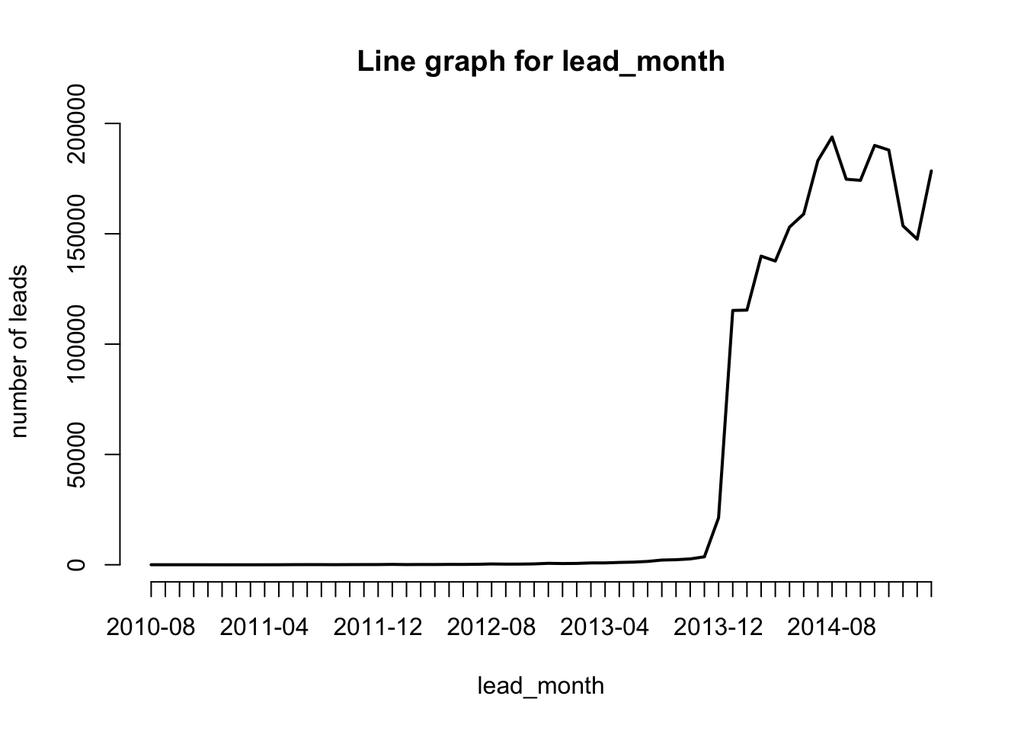

### 2. Generate a barplot for the top 20 dealer_state. You can to the table function to create a contingency table for dealer_state, sort by decreasing order, extra the first 20 elements and then draw a barplot. Which state has the most leads?

### Answer: CA has the most leads

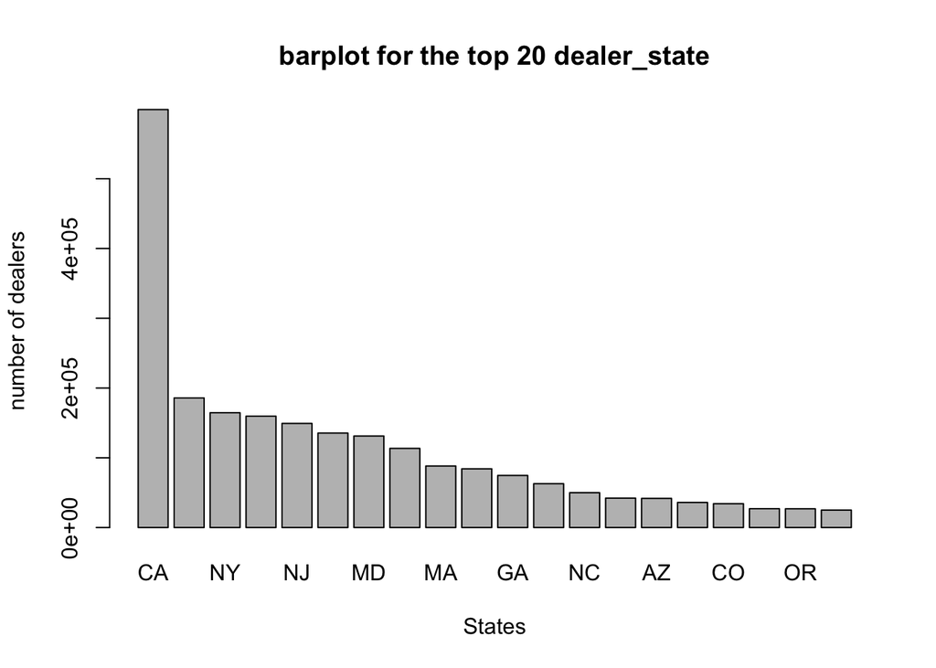

###3. Extract a subset where lead_year equals 2014 and dealer_state equals “CA” for the subse- quent analysis.

```r
subed<-subset(ed,lead_year=="2014")
subed<-subset(subed,subed$dealer_state=="CA")
```

### 4. Generate a barplot for the top 20 make. Which make(s) is the most popular one(s)?

#### Answer: HONDA

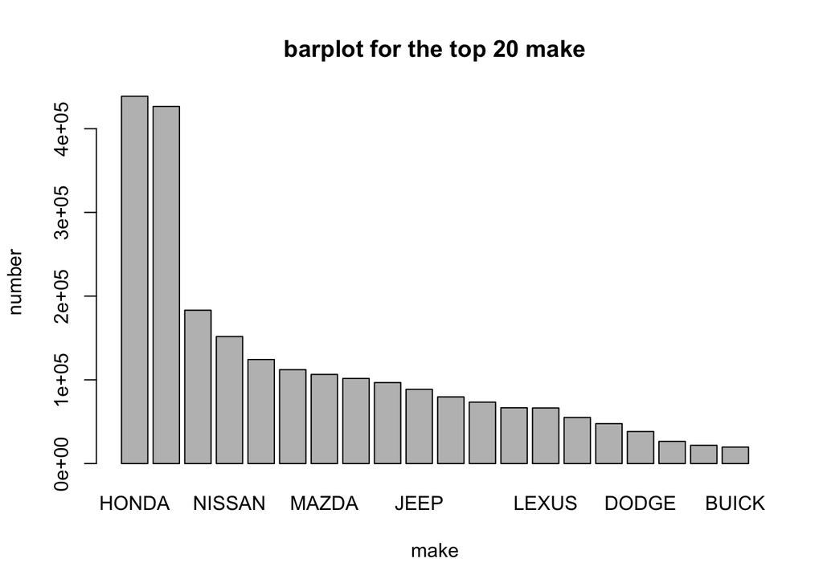

###5. Generate a boxplot for msrp for following groups: i. the leads of the top 1 make, ii. the leads of the top 2 make and iii. the leads of the other makes. Is the popularity of makes related to the price?

#### Answer:The retail price for the top 1 make, HONDA, is lower than the other two group’s retail price, and the retail price for the top 2 make is lower than other makes’ retail prices. There is a great possibility that the popularity of makes is related to the retail price, lower the price, higher the pupularity.

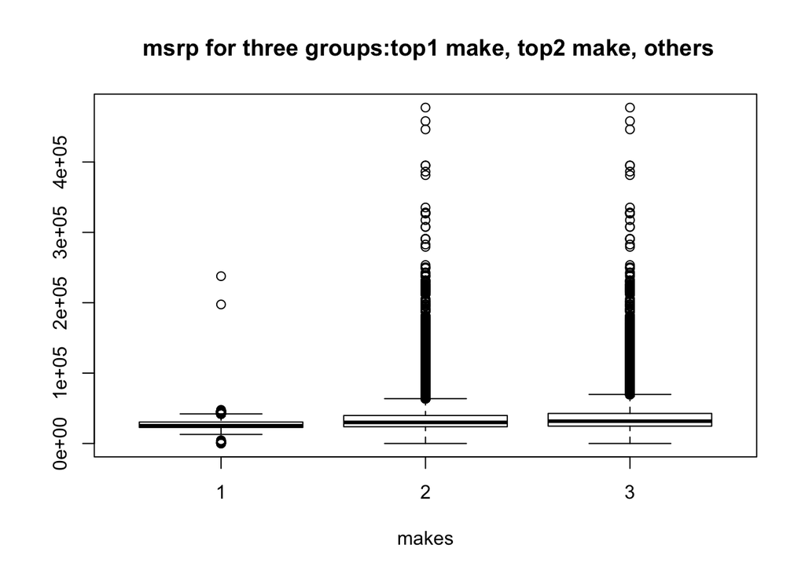

### 6. Create a aggregated table with three variables: i. dealer_zip, ii. msrp.med - the median msrp for each dealer_zip and iii. lead.count - the number of leads found for each dealer_zip. We encourage stuents to use the functions group_by and summarise from the package dplyr for this part. Using the aggregate function might be tedious since we want to use multiple functions for the aggregations.

```
## # A tibble: 4,993 × 3
##    dealer_zip msrp.med lead.count
##         <dbl>    <dbl>      <int>
## 1        1001  37950.0        457
## 2        1020  26790.0        524
## 3        1035       NA         70
## 4        1040  24296.0        126
## 5        1060  25622.5        763
## 6        1069       NA          3
## 7        1082       NA         41
## 8        1085  30675.0         70
## 9        1089  40825.0       2123
## 10       1095  28900.0        361
## # ... with 4,983 more rows
```

## – Irs Data:

### 1. Create a scatter plot matrix for all the 6 variables (except ZIPCODE). Describe and how the variables relate to each other. Is there any hypothesis you want to test? Just state your opinion.

#### Answer: The possible hypothesis I want to test is that is the mean difference between MARS1 and MARS2 significant

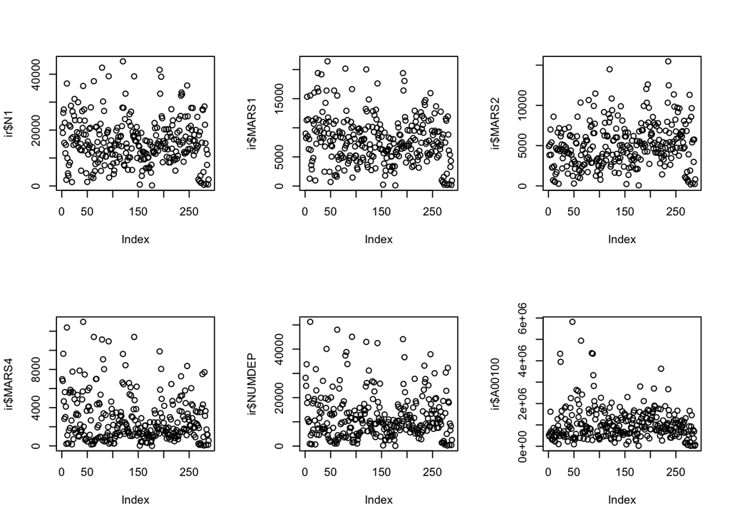

###– Cell Towers Data:

### 1. Generate a barplot for the top 20 ZIP. Which zip code with the most cell tower?

#### Answer: 91042

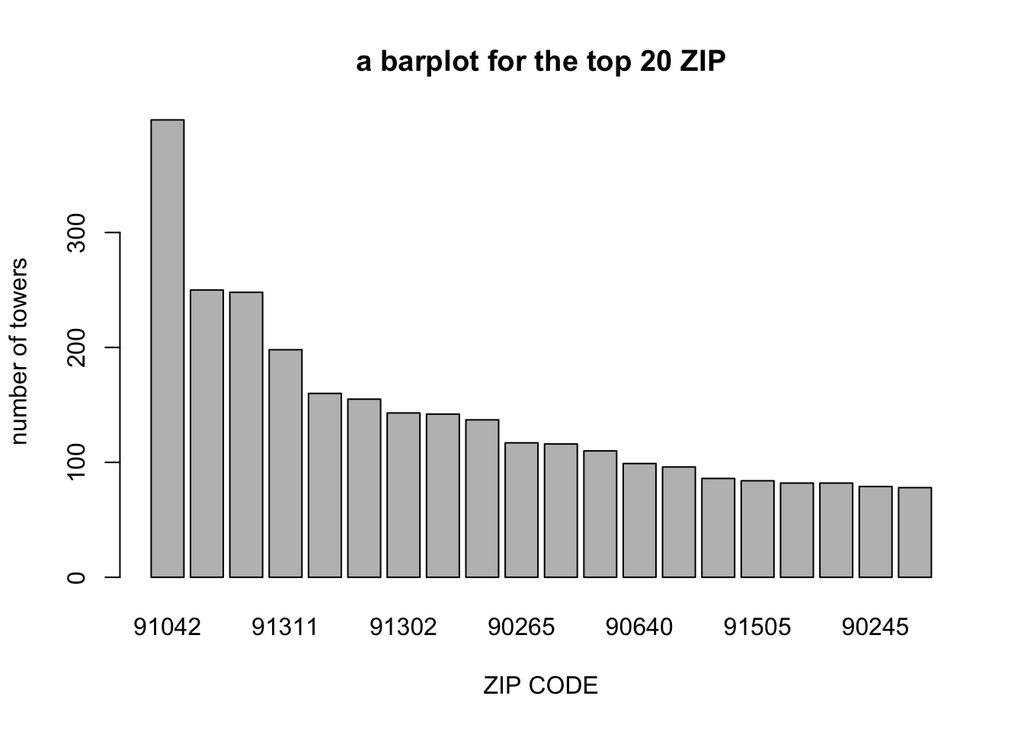

### 2. What cities are located in the zip code with the most cell tower? as shown in the output below

```
##  [1] "7920 Sunset Blvd"  "Burbank"           "Highway Highlands"
##  [4] "La Canada"         "La Crescenta"      "La Cresenta"
##  [7] "Lacrescenta"       "Los Angeles"       "Montrose"
## [10] "Montrous"          "Mount Lukens"      "Mt Lukens"
## [13] "Pasadena"          "Sunland"           "Sylmar"
## [16] "Tijunga"           "Tujunga"           "Valencia"
```

### 3. Create a aggregated table with three variables: i. ZIP, ii. cel.count - the number of cell towers in each ZIP. iii. lon.med - the median longitude for each ZIP. iv. lat.med - the median latitude for each ZIP. Again, we encourage students to use the functions group_by and summarise from the package dplyr for this part.

```
## # A tibble: 353 × 4
##      ZIP cel.count   lon.med  lat.med
##    <int>     <int>     <dbl>    <dbl>
## 1  90001        14 -118.2467 33.96556
## 2  90002         8 -118.2406 33.95167
## 3  90003        14 -118.2761 33.97028
## 4  90004        11 -118.3089 34.07611
## 5  90005        14 -118.2910 34.06181
## 6  90006         6 -118.2914 34.05208
## 7  90007        23 -118.2764 34.02778
## 8  90008        44 -118.3619 34.00667
## 9  90010         4 -118.3165 34.06167
## 10 90011         6 -118.2553 34.01139
## # ... with 343 more rows
```

# • Merge/Join your datasets.

### 1. Append the information in the aggregated table from the Edmund data to the Irs dataset. That is,we want perform left join to that two table by the zip code and keep all the observations in Irs.

### 2. Again, append the information in the aggregated table from the Cell Towers data to the mergeddataset from the previous step.

### 3. How many variables are there in the merged dataset?

### Answer:13

```
## [1] 13
```

# t-test:

### 1. Back to the boxplot you generated for msrp by three groups of make, perform the two-sided two-sample t-test for each pair of groups (3 times in total) to test the null hypothesis, H0 : the mean values for the two group are the same.

```
##
##  Welch Two Sample t-test
##
## data:  Top2 and Top1
## t = 93.968, df = 123490, p-value < 2.2e-16
## alternative hypothesis: true difference in means is not equal to 0
## 95 percent confidence interval:
##  3696.742 3854.240
## sample estimates:
## mean of x mean of y
##  30708.44  26932.95
```

```
##
##  Welch Two Sample t-test
##
## data:  Top1 and Others
## t = -237.23, df = 321530, p-value < 2.2e-16
## alternative hypothesis: true difference in means is not equal to 0
## 95 percent confidence interval:
##  -8508.350 -8368.913
## sample estimates:
## mean of x mean of y
##  26932.95  35371.58
```

```
##
##  Welch Two Sample t-test
##
## data:  Others and Top2
## t = 107.21, df = 181100, p-value < 2.2e-16
## alternative hypothesis: true difference in means is not equal to 0
## 95 percent confidence interval:
##  4577.891 4748.390
## sample estimates:
## mean of x mean of y
##  35371.58  30708.44
```

# Linear regression.

## 1. Is there any pair of variables from two different datasets has a significant linear relationship?

### answer: From the plot matrix and correlation matrixes there are potential linear relationships between lat.med and ZIPCODE,lon.med and ZIPCODE, lon.med and A00100,

## iii. is any other variable correlated with the location?

### answer:lat.med has a correlation with ZIPCODE 0.677 which is considerable high

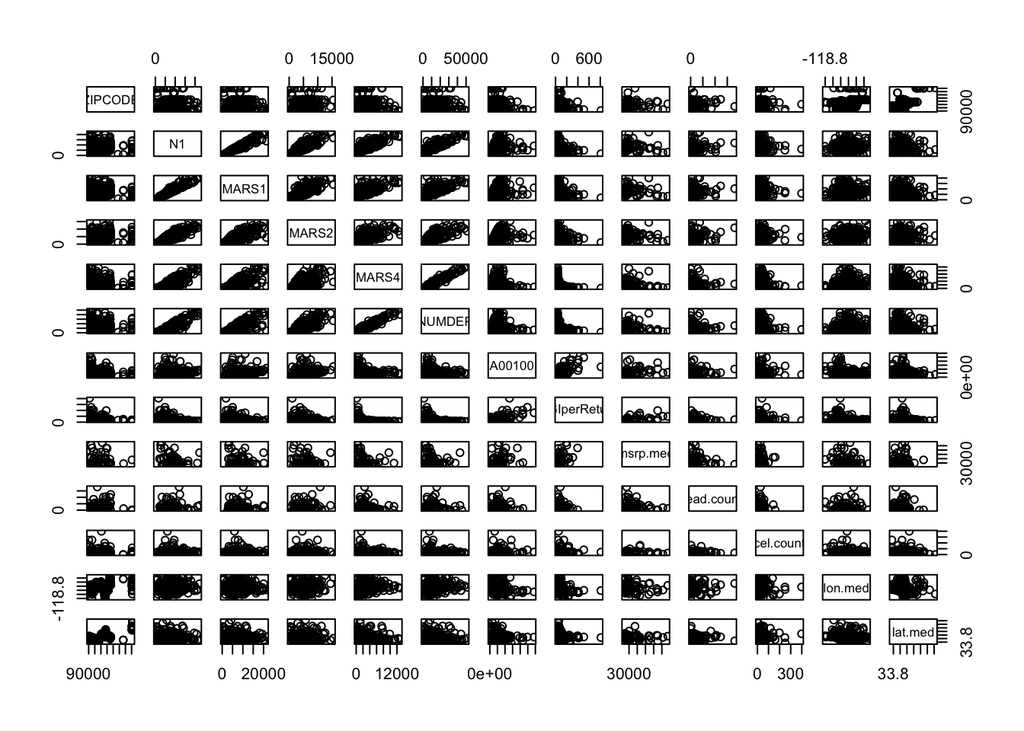

```
##                  ZIPCODE         N1      MARS1      MARS2      MARS4
## ZIPCODE       1.00000000 -0.1117121 -0.2081346  0.1077205 -0.1459958
## N1           -0.11171210  1.0000000  0.9498016  0.8653318  0.8266710
## MARS1        -0.20813456  0.9498016  1.0000000  0.7458430  0.7023785
## MARS2         0.10772050  0.8653318  0.7458430  1.0000000  0.5621530
## MARS4        -0.14599579  0.8266710  0.7023785  0.5621530  1.0000000
## NUMDEP       -0.05792026  0.8800680  0.7252312  0.7231162  0.9633253
## A00100       -0.17209071  0.2733214  0.3303096  0.4122488 -0.1000588
## AGIperReturn -0.14249609 -0.3070569 -0.2644844 -0.1640142 -0.4210032
## msrp.med              NA         NA         NA         NA         NA
## lead.count            NA         NA         NA         NA         NA
## cel.count             NA         NA         NA         NA         NA
## lon.med               NA         NA         NA         NA         NA
## lat.med               NA         NA         NA         NA         NA
##                    NUMDEP       A00100 AGIperReturn msrp.med lead.count
## ZIPCODE      -0.057920261 -0.172090714   -0.1424961       NA         NA
## N1            0.880068005  0.273321396   -0.3070569       NA         NA
## MARS1         0.725231192  0.330309555   -0.2644844       NA         NA
## MARS2         0.723116241  0.412248806   -0.1640142       NA         NA
## MARS4         0.963325280 -0.100058787   -0.4210032       NA         NA
## NUMDEP        1.000000000  0.009851599   -0.3773184       NA         NA
## A00100        0.009851599  1.000000000    0.6578624       NA         NA
## AGIperReturn -0.377318422  0.657862432    1.0000000       NA         NA
## msrp.med               NA           NA           NA        1         NA
## lead.count             NA           NA           NA       NA          1
## cel.count              NA           NA           NA       NA         NA
## lon.med                NA           NA           NA       NA         NA
## lat.med                NA           NA           NA       NA         NA
##              cel.count lon.med lat.med
## ZIPCODE             NA      NA      NA
## N1                  NA      NA      NA
## MARS1               NA      NA      NA
## MARS2               NA      NA      NA
## MARS4               NA      NA      NA
## NUMDEP              NA      NA      NA
## A00100              NA      NA      NA
## AGIperReturn        NA      NA      NA
## msrp.med            NA      NA      NA
## lead.count          NA      NA      NA
## cel.count            1      NA      NA
## lon.med             NA       1      NA
## lat.med             NA      NA       1
```

```
##                  ZIPCODE          N1        MARS1       MARS2       MARS4
## ZIPCODE       1.00000000 -0.07218206 -0.169321292  0.14829278 -0.12093532
## N1           -0.07218206  1.00000000  0.947853847  0.86411418  0.82745029
## MARS1        -0.16932129  0.94785385  1.000000000  0.74205720  0.69733085
## MARS2         0.14829278  0.86411418  0.742057201  1.00000000  0.56437937
## MARS4        -0.12093532  0.82745029  0.697330849  0.56437937  1.00000000
## NUMDEP       -0.02999589  0.87860437  0.718317111  0.72183648  0.96426233
## A00100       -0.14680053  0.24910739  0.309414924  0.39109167 -0.11872406
## AGIperReturn -0.13760728 -0.31318729 -0.269988574 -0.16751558 -0.42448137
## msrp.med              NA          NA           NA          NA          NA
## lead.count            NA          NA           NA          NA          NA
## cel.count    -0.01063052  0.06043601  0.050606832  0.12769734 -0.02285447
## lon.med       0.28839321  0.09646349  0.008538494  0.13996549  0.15989006
## lat.med       0.67749572 -0.13326382 -0.163279800 -0.01426576 -0.15810886
##                   NUMDEP      A00100 AGIperReturn msrp.med lead.count
## ZIPCODE      -0.02999589 -0.14680053 -0.137607278       NA         NA
## N1            0.87860437  0.24910739 -0.313187286       NA         NA
## MARS1         0.71831711  0.30941492 -0.269988574       NA         NA
## MARS2         0.72183648  0.39109167 -0.167515578       NA         NA
## MARS4         0.96426233 -0.11872406 -0.424481369       NA         NA
## NUMDEP        1.00000000 -0.01199834 -0.380573503       NA         NA
## A00100       -0.01199834  1.00000000  0.669332230       NA         NA
## AGIperReturn -0.38057350  0.66933223  1.000000000       NA         NA
## msrp.med              NA          NA           NA        1         NA
## lead.count            NA          NA           NA       NA          1
## cel.count     0.01077182  0.14746389  0.068824007       NA         NA
## lon.med       0.18536874 -0.27230940 -0.299190953       NA         NA
## lat.med      -0.10460241 -0.07901082 -0.005613102       NA         NA
##                cel.count      lon.med      lat.med
## ZIPCODE      -0.01063052  0.288393212  0.677495721
## N1            0.06043601  0.096463488 -0.133263819
## MARS1         0.05060683  0.008538494 -0.163279800
## MARS2         0.12769734  0.139965490 -0.014265761
## MARS4        -0.02285447  0.159890063 -0.158108861
## NUMDEP        0.01077182  0.185368742 -0.104602406
## A00100        0.14746389 -0.272309400 -0.079010821
## AGIperReturn  0.06882401 -0.299190953 -0.005613102
## msrp.med              NA           NA           NA
## lead.count            NA           NA           NA
## cel.count     1.00000000 -0.023491406  0.017166654
## lon.med      -0.02349141  1.000000000 -0.145621339
## lat.med       0.01716665 -0.145621339  1.000000000
```

```
##                   ZIPCODE           N1       MARS1      MARS2       MARS4
## ZIPCODE       1.000000000  0.006547035 -0.08824401  0.1360332  0.00265164
## N1            0.006547035  1.000000000  0.94895880  0.8952202  0.83031989
## MARS1        -0.088244006  0.948958798  1.00000000  0.7714838  0.71294265
## MARS2         0.136033201  0.895220211  0.77148381  1.0000000  0.61549117
## MARS4         0.002651640  0.830319891  0.71294265  0.6154912  1.00000000
## NUMDEP        0.058204456  0.897806067  0.75191345  0.7824874  0.95791993
## A00100       -0.161823289  0.254839155  0.29987158  0.3951019 -0.12495755
## AGIperReturn -0.146674798 -0.336410078 -0.29943075 -0.1757996 -0.49057013
## msrp.med     -0.041398856 -0.209131629 -0.20676299 -0.1242403 -0.24689652
## lead.count    0.070307779 -0.012112691 -0.05506478  0.1068176 -0.08996160
## cel.count              NA           NA          NA         NA          NA
## lon.med                NA           NA          NA         NA          NA
## lat.med                NA           NA          NA         NA          NA
##                   NUMDEP      A00100 AGIperReturn    msrp.med  lead.count
## ZIPCODE       0.05820446 -0.16182329  -0.14667480 -0.04139886  0.07030778
## N1            0.89780607  0.25483915  -0.33641008 -0.20913163 -0.01211269
## MARS1         0.75191345  0.29987158  -0.29943075 -0.20676299 -0.05506478
## MARS2         0.78248739  0.39510186  -0.17579957 -0.12424030  0.10681757
## MARS4         0.95791993 -0.12495755  -0.49057013 -0.24689652 -0.08996160
## NUMDEP        1.00000000  0.01938832  -0.42188228 -0.21633294 -0.04865640
## A00100        0.01938832  1.00000000   0.72078291  0.25491407 -0.04103924
## AGIperReturn -0.42188228  0.72078291   1.00000000  0.49941653 -0.08705794
## msrp.med     -0.21633294  0.25491407   0.49941653  1.00000000 -0.22196121
## lead.count   -0.04865640 -0.04103924  -0.08705794 -0.22196121  1.00000000
## cel.count             NA          NA           NA          NA          NA
## lon.med               NA          NA           NA          NA          NA
## lat.med               NA          NA           NA          NA          NA
##              cel.count lon.med lat.med
## ZIPCODE             NA      NA      NA
## N1                  NA      NA      NA
## MARS1               NA      NA      NA
## MARS2               NA      NA      NA
## MARS4               NA      NA      NA
## NUMDEP              NA      NA      NA
## A00100              NA      NA      NA
## AGIperReturn        NA      NA      NA
## msrp.med            NA      NA      NA
## lead.count          NA      NA      NA
## cel.count            1      NA      NA
## lon.med             NA       1      NA
## lat.med             NA      NA       1
```

### 2. Fit a linear model to the pair of variables you picked in the previous step. Assign one of them to be the outcome variable (y) and the other to be the preditor (x) using your knowledge. Display the summary output of the linear model and the diagnostic plots.

```r
m1<-lm(ir$lat.med~ir$ZIPCODE)
summary(m1)
```

```
##
## Call:
## lm(formula = ir$lat.med ~ ir$ZIPCODE)
##
## Residuals:
##      Min       1Q   Median       3Q      Max
## -0.44766 -0.10013  0.02242  0.09664  0.55957
##
## Coefficients:
##              Estimate Std. Error t value Pr(>|t|)
## (Intercept) 2.032e+01  8.974e-01   22.65   <2e-16 ***
## ir$ZIPCODE  1.513e-04  9.867e-06   15.33   <2e-16 ***
## ---
## Signif. codes:  0 '***' 0.001 '**' 0.01 '*' 0.05 '.' 0.1 ' ' 1
##
## Residual standard error: 0.1431 on 277 degrees of freedom
##   (9 observations deleted due to missingness)
## Multiple R-squared:  0.459,  Adjusted R-squared:  0.457
## F-statistic:   235 on 1 and 277 DF,  p-value: < 2.2e-16
```

# Custom functions.

|  | Number of cell Tower | Number of Returns | Number of Leads |
| --- | --- | --- | --- |
| 90001 | 14 | 20970 | 736 |
| 19428 | 0 | 0 | 0 |
| 00033 | 0 | 0 | 0 |

|  | Number of cell Tower | Number of Returns | Number of Leads |
| --- | --- | --- | --- |
| 90001 | 14 | 20970 | 736 |
| 19428 | 0 | 0 | 0 |
| 00033 | 0 | 0 | 0 |
| 1004 | 0 | 0 | 0 |

|  | Number of cell Tower | Number of Returns | Number of Leads |
| --- | --- | --- | --- |
| 90001 | 14 | 20970 | 736 |
| 19428 | 0 | 0 | 0 |
| 00033 | 0 | 0 | 0 |
| NA | NA | NA | NA |

# Results and Conclusions.

### Describe the results of the t-test. Interpret the output and explain what the result means in the context of the question that motivated using the t-test.

#### Answer:The p value for are three t-test performed are all significantly small thus we reject the null hypothesis that the mean values for the two group are the same. And we conclude that the mean values for the three groups are not the same.

### Interpret the results of your linear model. Specifically, interpret what the slope coefficient means and how strongly correlated the variables are. Give some suggestions to improve your model (for example, do some transformation or exclude potential outliers).

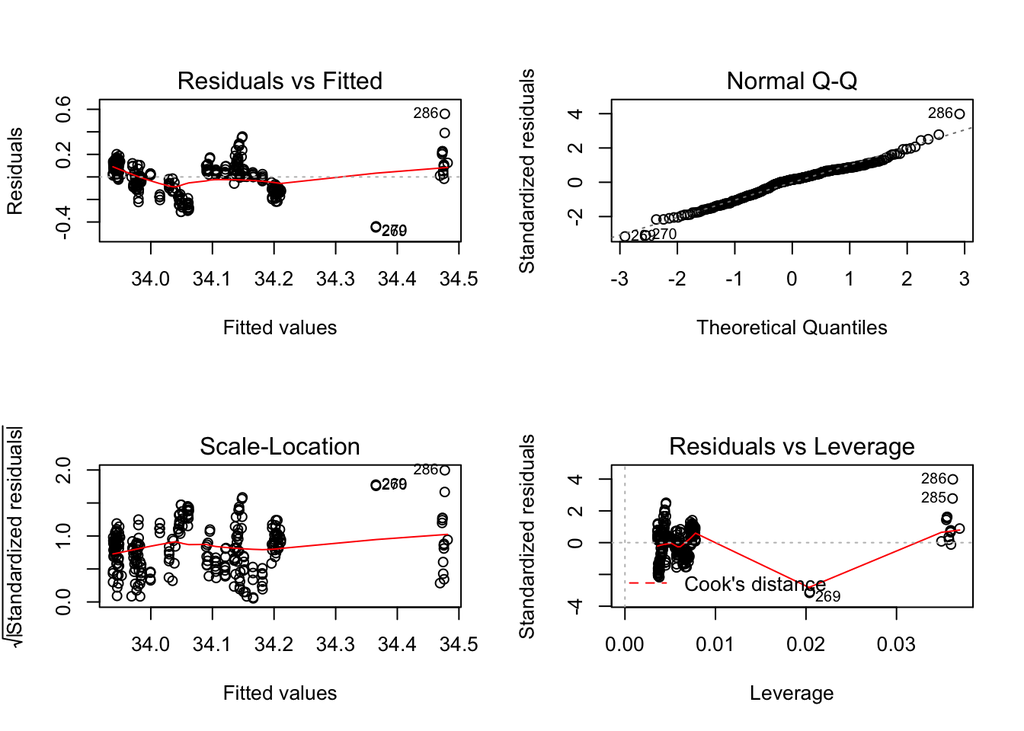

### Demonstrate that the function you created in the analysis portion works.

#### Answer: as the code output shown, my function output is correct.

```r
f( c('90015', '90002','90013'))
```

|  | Number of cell Tower | Number of Returns | Number of Leads |
| --- | --- | --- | --- |
| 90015 | 43 | 7440 | 5154 |
| 90002 | 8 | 18960 | NA |
| 90013 | 29 | 4490 | NA |

```r
ir[ir$ZIPCODE=='90015',]
```

```
##    ZIPCODE   N1 MARS1 MARS2 MARS4 NUMDEP A00100 AGIperReturn msrp.med
## 14   90015 7440  4280  1440  1610   5470 436491     58.66815    23755
##    lead.count cel.count   lon.med  lat.med
## 14       5154        43 -118.2664 34.04194
```

```r
ir[ir$ZIPCODE=='90002',]
```

```
##   ZIPCODE    N1 MARS1 MARS2 MARS4 NUMDEP A00100 AGIperReturn msrp.med
## 2   90002 18960  8230  3830  6800  24850 462823      24.4105       NA
##   lead.count cel.count   lon.med  lat.med
## 2         NA         8 -118.2406 33.95167
```

```r
ir[ir$ZIPCODE=='90013',]
```

```
##    ZIPCODE   N1 MARS1 MARS2 MARS4 NUMDEP A00100 AGIperReturn msrp.med
## 12   90013 4490  3580   550   280    780 247312     55.08062       NA
##    lead.count cel.count   lon.med  lat.med
## 12         NA        29 -118.2486 34.04806
```